# Snake Basin Steelhead Kelt Analysis

Ryan N. Kinzer<sup>1,✉</sup>, and Mike Ackerman<sup>1,✉</sup>

25 June, 2026

<sup>1</sup> Nez Perce Tribe, Department of Fisheries Resources Management, 14054 Burr Dr., McCall, Idaho, 83638, USA

<sup>✉</sup> Correspondence: Ryan N. Kinzer <ryank@nezperce.org>, Mike Ackerman <mikea@nezperce.org>

[figure not shown]

[figure not shown]

DRAFT

# 1 Data Sources

We evaluated kelting rates of natural-origin adult steelhead observed spawning in Snake River tributaries upstream of Lower Granite Dam (LGR) moving back downstream past LGR, simultaneously estimating the kelt detection probability of LGR. The dataset used in this analysis comprises of observations of PIT-tagged natural-origin adult steelhead (newly or previously tagged) trapped at the LGR adult ladder, beginning with spawn year 2010, and then subsequently detected near the spawning grounds at instream PIT-tag detection systems (IPTDS) or mark-recapture-recovery (MRR) sites. Post-spawn, PIT-tagged adults can additionally be “re-detected” moving downstream past LGR, at any downriver dam, or in the Columbia River estuary.

We generate the dataset by first compiling a list of PIT-tag observations for adult steelhead with *valid* PIT-tag codes collected at the LGR adult trap between July 1 and June 30 comprising each spawn year (Ogden 2020; Baum et al. 2023). All phenotypic natural-origin fish (i.e., present adipose fin and absence of a coded-wire tag) are included as part of the *valid* tag list. Phenotypic natural-orgin fish of hatchery-origin can later be identified using parentage-based tagging (Steele et al. 2013, 2019; Baum et al. 2023).

A PIT-tag code was considered *valid* if the adult steelhead was trapped while ascending the LGR fish ladder during a systematic subsampling period, had a fork length (FL) greater than 30 cm, and was not missing data for any of the following fields: date of collection, species, FL, origin (hatchery or wild), or adipose fin status (ad-clipped or ad-intact) within the LGR trapping database (Baum et al. 2023). Once the valid tag list was developed, we retrieved all PIT-tag interrogations for each code using the complete tag history query from [PTAGIS](https://www.ptagis.org). Observations were then processed using the statistical programming language R (R Core Team 2025) and the [PITcleanr](https://kevinsee.github.io/PITcleanr/) package (See et al. 2024). PIT-tag observations and data processing scripts are maintained within the SnakeRiverFishStatus GitHub repository.

The complete tag histories were initially processed using the `PITcleanr::compress()` function (See et al. 2024). This function, along with a supplied configuration file, collapsed multiple PIT-tag interrogations at the same location and within a similar time frame into a single record, retaining only essential information: the PIT-tag code, observation location (i.e., node), and the minimum and maximum timestamps of observations at that location (i.e., IPTDS, MRR site, or dam). For instance, all PIT-tag detection sites at Bonneville Dam (e.g., BCC, B2J, etc.) were merged into a single node, while LGR sites were categorized into a downstream migration node (GRJ, GRS) and an upstream migration node (GRA, LGRLDR, LGR). Similar to Bonneville Dam, all detection sites within a dam between LGR and Bonneville were merged into their own node. All detections upstream of LGR remained distinct to facilitate assignment of detections to specific spawning locations and identify movement direction. Finally, the dataset was truncated to include only observations occuring after an upstream-migrating steelhead was first detected at the LGR adult trap, excluding all juvenile and pre-return adult observations.

The resulting dataset consists of PIT-tag observations from a random sample of adult steelhead migrating past LGR and all subsequent detections of fish migrating during three distinct life stages: upstream towards spawning areas (spawners), downstream post-spawning (kelt), and returning upstream again through the hydrosystem (repeat spawners). A simple rule set was then applied to classify observations to locations and each life stage using functions maintained in the SnakeRiverKelt GitHub repository. The kelt stage was assigned to observations occurring at least five days after the last upstream spawner movement, observations indicating a downstram movement, and any detections at the lower Snake and Columbia river hydrosystems after April 20. The repeat spawner stage was assigned to all observations following the first upstream migration in any spawn year beyond the fish’s initial spawn year.

We additionally received a list of PIT-tagged adult steelhead kelts collected from the LGR juvenile bypass for the kelt reconditioning program starting in 2016 to 2021. Because these kelts are removed from the river for reconditioning, they were filtered from our evaluation of kelting and detection rates at LGR. The list consists of adults newly tagged at LGR and part of the *valid* list and previously tagged, which may or may not be within the *valid* tag list.

Finally, we refined our dataset to include only fish with a final designated species-run-rear (SRR) code of “32W” (i.e., steelhead, summer-run, wild). Hatchery-identified adults from the *valid* tag list were excluded, as they are not retained for natural-origin adult escapement analyses in the standard SnakeRiverFishStatus workflow, and the kelt reconditioning program focuses solely on natural-origin adults. Additionally, we removed a small number of fish with undetermined sex.

Kelts removed from the river for the reconditioning program were not included in our analysis of kelting and detection probability rates at LGR; however, their data were retained for comparison with all spawners observed as kelts at LGR and downstream.

In the 15 years of observation data, we have observed 16,273 PIT-tagged adult steelhead at Snake River spawning locations, after refining our dataset. Tables 1.1 and 1.2 show the number of these unique PIT-tagged spawners for each spawn year and within each Snake River population upstream of LGR. Additionally, the tables include the number of those spawners observed as kelt at LGR and downstream (i.e., below) of LGR.

Table 1.1: Natural-origin PIT-tagged steelhead released from Lower Granite Dam (LGR), observed upstream as spawners, and subsequent detections of kelt at Lower Snake and Columbia River hydrosystem facilities. Reconditioned kelt indicates spawners collected for reconditioning (i.e., removed from the river) and subsequently removed from kelting rate and detection analyses.

| Spawn Year | Released LGR | Spawner Obs | Kelt at LGR | Reconditioned Kelt | Kelt Below LGR |
| --- | --- | --- | --- | --- | --- |
| 2010 | 2,198 | 469 | 9 | 0 | 48 |
| 2011 | 2,723 | 1,015 | 36 | 0 | 111 |
| 2012 | 2,540 | 1,102 | 44 | 0 | 177 |
| 2013 | 3,330 | 1,198 | 20 | 0 | 146 |
| 2014 | 3,415 | 1,227 | 83 | 0 | 228 |
| 2015 | 3,863 | 1,287 | 28 | 0 | 168 |
| 2016 | 4,214 | 1,339 | 68 | 5 | 224 |
| 2017 | 2,930 | 1,023 | 40 | 11 | 132 |
| 2018 | 2,231 | 906 | 46 | 15 | 170 |
| 2019 | 1,715 | 855 | 61 | 20 | 175 |
| 2020 | 2,286 | 1,056 | 184 | 11 | 139 |
| 2021 | 3,055 | 1,579 | 284 | 3 | 164 |
| 2022 | 1,879 | 858 | 185 | 0 | 108 |
| 2023 | 2,608 | 1,163 | 260 | 0 | 128 |
| 2024 | 2,995 | 1,196 | 167 | 0 | 133 |
| Total | 41,982 | 16,273 | 1,515 | 65 | 2,251 |

TRT POPID

Spawner Obs

Kelt at LGR

Reconditioned Kelt

Kelt Below LGR

Clearwater River

CRLMA-s

961

64

0

152

Clearwater River

CRLOC-s

766

84

2

80

Clearwater River

CRLOL-s

444

34

0

43

Clearwater River

CRSEL-s

607

74

1

49

Clearwater River

CRSFC-s

766

37

1

49

Grande Ronde River

GRJOS-s

2,150

188

13

287

Grande Ronde River

GRLMT-s

356

61

3

51

Grande Ronde River

GRUMA-s

1,618

200

10

337

Grande Ronde River

GRWAL-s

1,143

143

7

170

Imnaha River

IRMAI-s

3,087

316

21

445

Lower Snake

SNASO-s

1,158

50

0

73

Salmon River

MFBIG-s

477

44

3

78

Salmon River

MFUMA-s

33

9

0

6

Salmon River

SFMAI-s

1,177

71

0

192

Salmon River

SFSEC-s

195

17

0

36

Salmon River

SREFS-s

48

1

0

4

Salmon River

SRLEM-s

436

30

1

75

Salmon River

SRLSR-s

56

10

0

2

Salmon River

SRNFS-s

97

10

2

19

Salmon River

SRPAH-s

98

8

0

15

Salmon River

SRPAN-s

235

30

0

34

Salmon River

SRUMA-s

365

34

1

54

Total

16,273

1,515

65

2,251

The largest (i.e., greatest fork length) spawners typically occur in the Lochsa River (CRLOC-s), SF Salmon River (SFMAI-s), South Fork Clearwater River (CRSFC-s), Lolo Creek (CRLOL-s), Selway River (CRSEL-s), Sesech River (SFSEC-s), and Middle Fork Salmon River ((MFUMA-s and MFBIG-s) populations (Figure 1.1). The proportion of females returning to each population is lowest in the Little Salmon River (SRLSR-s) and upper mainstem Salmon River (SRUMA-s) populations and highest in the Pahsimeroi (SRPAH-s) and Panther Creek (SRPAN-s) populations (Figure 1.2).

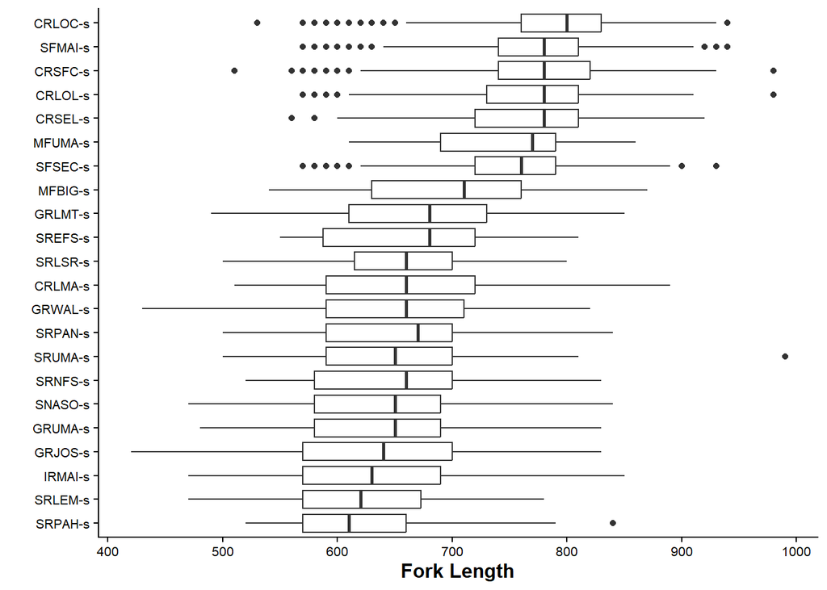

Figure 1.1: Length distributions of steelhead sampled at Lower Granite Dam and later detected in spawning areas, all spawn years.

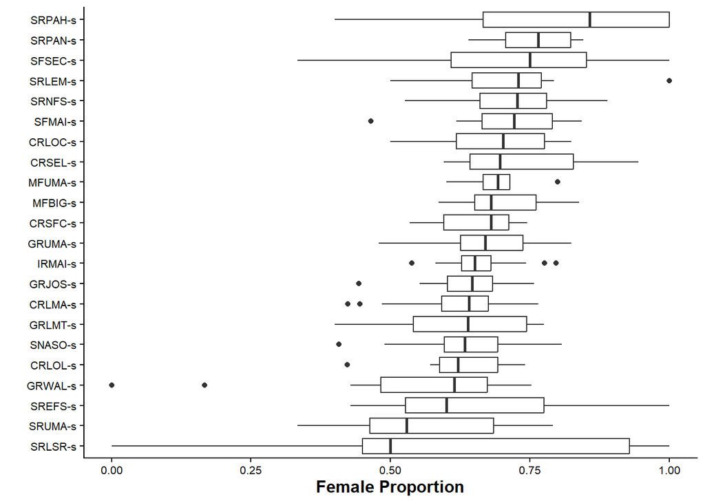

Figure 1.2: Distributions of the proportion of female steelhead, among spawn years, sampled at Lower Granite Dam and later detected in spawning areas.

# 2 Analysis

## 2.1 Reconditioned vs. All Kelts Comparison

We compared kelts collected by the reconditioning program in spawn year 2016 - 2021 to all kelts observed at LGR and/or at downstream hydropower systems to evaluate whether reconditioned kelts are representative of all kelts at-large (i.e., in-river migrating downstream past LGR). Figure 2.1 provides comparisons of size, run-timing (i.e., collection date at LGR during upstream migration), and proportions of genetic stocks and kelts previously observed at upstream spawning locations.

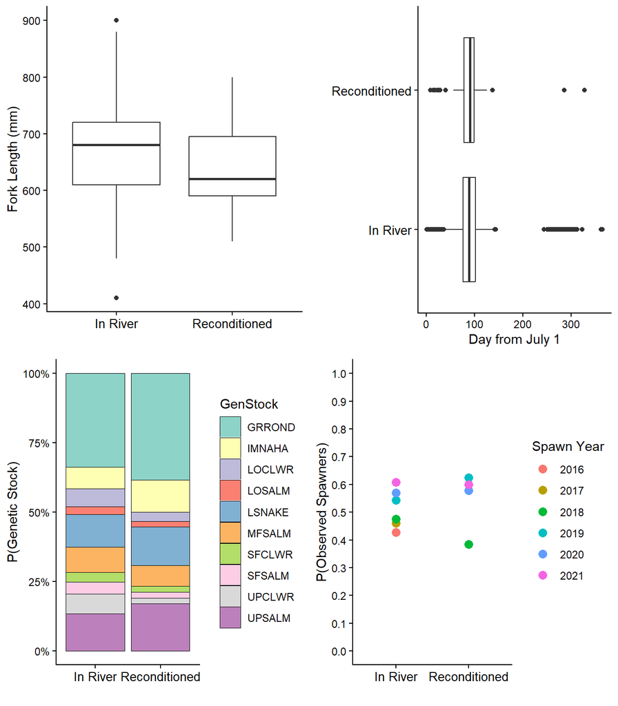

Figure 2.1: Comparison of all kelts observed at LGR or at downstream hydropower facilities (In River) to kelts collected by the reconditioning program (Reconditioned), spawn year 2016 - 2021, from those within the valid tag list. Comparisons include length, collection date at Lower Granite Dam from July 1, genetic stock proportions, and proportion of individuals observed at spawning sites.

## 2.2 Kelt Survival and Detection Modeling

We estimated post-spawn steelhead apparent survival (i.e., surviving and migrating) to LGR using a Cormack-Jolly-Seber (CJS) model (Lebreton et al. 1992). The likelihood function for an individual $i$ in group $g$ (e.g., a specific spawn year, population, and/or other covariate) follows:

$$L = \prod_{i=1}^{n} \prod_{t=1}^{T} P(y_{it} | \phi^g, p^g)$$

where, $y_{it} = 1$ if individual $i$ is observed at time $t$, and $y_{it} = 0$ if the individual was not observed. $\phi_t^g$ is the probability of survival from $t$ to $t+1$ for group $g$, and $p_t^g$ is the probability of detection at $t$, given the individual is alive.

Since spawn year, population, and sex may explain variation in survival and detection probabilities, we incorporated these as fixed effects using a logit-link with the general model structure as (excluding possible interactions):

$$\text{logit}(\phi_t) = \beta_0 + \beta_1 (\text{spawn year}) + \beta_2 (\text{population}) + \beta_3 (\text{sex})$$

$$\text{logit}(p_t) = \alpha_0 + \alpha_1 (\text{spawn year}) + \alpha_2 (\text{population}) + \alpha_3 (\text{sex})$$

where, $\beta_0, \beta_1, \beta_2, \beta_3$ are coefficients for survival ($\phi$) and $\alpha_0, \alpha_1, \alpha_2, \alpha_3$ are coefficients for detection ($p$). Biologically meaningful interaction terms were also included in candidate models; for example, spawn year X population and population x sex to examine if survival and detection probabilities vary differently across the two interaction terms.

We fit multiple candidate models with different variations of fixed effects and interactions, and then determined the best-fitting model using Akaike’s Information Criterion (AIC) (Akaike 1974) calculated as:

$$AIC = -2 \log L + 2K$$

where, $L$ is the likelihood of the model given the data and $K$ is the number of estimated parameters. The model with the lowest AIC value was selected as the most parsimonious and best-fitting model.

All models were fit using the `marked::cmr()` (Laake et al. 2013) function in R (R Core Team 2025).

# 3 Results

Table 3.1: Model selection criteria for fitted Cormack-Jolly-Seber models.

| ID | Model | Parameters | AIC | Delta AIC | Weight | -2Loglik |
| --- | --- | --- | --- | --- | --- | --- |
| 29 | Phi(~year + pop * sex + time)p(~year * time + sex) | 90 | 20757.24 | 0.0000000 | 0.5381978 | 20577.24 |
| 30 | Phi(~year + pop * sex + time)p(~year * time) | 89 | 20757.54 | 0.3061839 | 0.4618010 | 20579.54 |
| 28 | Phi(~year + pop + sex + time)p(~year * time) | 68 | 20783.85 | 26.6165204 | 0.0000009 | 20647.85 |
| 27 | Phi(~year + pop + sex + time)p(~year * time + sex) | 69 | 20785.85 | 28.6100388 | 0.0000003 | 20647.85 |
| 9 | Phi(~pop + sex + time)p(~year * time + sex) | 55 | 20829.70 | 72.4628114 | 0.0000000 | 20719.70 |
| 10 | Phi(~pop + sex + time)p(~year * time) | 54 | 20836.16 | 78.9222776 | 0.0000000 | 20728.16 |
| 25 | Phi(~year + pop + time)p(~year * time + sex) | 68 | 20857.14 | 99.9012732 | 0.0000000 | 20721.14 |
| 24 | Phi(~year + mpg + sex + time)p(~year * time) | 51 | 20870.41 | 113.1772537 | 0.0000000 | 20768.41 |
| 23 | Phi(~year + mpg + sex + time)p(~year * time + sex) | 52 | 20872.31 | 115.0743618 | 0.0000000 | 20768.31 |
| 3 | Phi(~mpg + sex + time)p(~year * time + sex) | 38 | 20915.22 | 157.9840666 | 0.0000000 | 20839.22 |
| 4 | Phi(~mpg + sex + time)p(~year * time) | 37 | 20921.08 | 163.8467572 | 0.0000000 | 20847.08 |
| 21 | Phi(~year + mpg + time)p(~year * time + sex) | 51 | 20926.74 | 169.5082957 | 0.0000000 | 20824.74 |
| 11 | Phi(~pop * time)p(~year * time + sex) | 75 | 20945.61 | 188.3764005 | 0.0000000 | 20795.61 |
| 7 | Phi(~pop + time)p(~year * time + sex) | 54 | 20953.40 | 196.1612242 | 0.0000000 | 20845.40 |
| 5 | Phi(~mpg * time)p(~year * time + sex) | 41 | 21019.10 | 261.8656188 | 0.0000000 | 20937.10 |
| 32 | Phi(~year + sex + time)p(~year * time) | 47 | 21022.46 | 265.2203903 | 0.0000000 | 20928.46 |
| 31 | Phi(~year + sex + time)p(~year * time + sex) | 48 | 21022.63 | 265.3913752 | 0.0000000 | 20926.63 |
| 1 | Phi(~mpg + time)p(~year * time + sex) | 37 | 21041.11 | 283.8739443 | 0.0000000 | 20967.11 |
| 13 | Phi(~sex + time)p(~year * time + sex) | 34 | 21067.97 | 310.7323704 | 0.0000000 | 20999.97 |
| 15 | Phi(~sex * time)p(~year * time + sex) | 35 | 21068.80 | 311.5623060 | 0.0000000 | 20998.80 |
| 14 | Phi(~sex + time)p(~year * time) | 33 | 21068.87 | 311.6336798 | 0.0000000 | 21002.87 |
| 16 | Phi(~sex * time)p(~year * time) | 34 | 21070.87 | 313.6336281 | 0.0000000 | 21002.87 |
| 17 | Phi(<sub>time)p(</sub>year * time + sex) | 33 | 21091.69 | 334.4544530 | 0.0000000 | 21025.69 |
| 19 | Phi(~year + time)p(~year * time + sex) | 47 | 21103.50 | 346.2627410 | 0.0000000 | 21009.50 |
| 33 | Phi(~year * time)p(~year * time + sex) | 61 | 21114.95 | 357.7143202 | 0.0000000 | 20992.95 |
| 26 | Phi(~year + pop + time)p(~year * time) | 67 | 21346.68 | 589.4490317 | 0.0000000 | 21212.68 |
| 12 | Phi(~pop * time)p(~year * time) | 74 | 21353.88 | 596.6416743 | 0.0000000 | 21205.88 |
| 8 | Phi(~pop + time)p(~year * time) | 53 | 21360.08 | 602.8412763 | 0.0000000 | 21254.08 |
| 22 | Phi(~year + mpg + time)p(~year * time) | 50 | 21424.54 | 667.3071486 | 0.0000000 | 21324.54 |
| 6 | Phi(~mpg * time)p(~year * time) | 40 | 21427.10 | 669.8618876 | 0.0000000 | 21347.10 |
| 2 | Phi(~mpg + time)p(~year * time) | 36 | 21432.07 | 674.8325902 | 0.0000000 | 21360.07 |
| 18 | Phi(<sub>time)p(</sub>year * time) | 32 | 21600.80 | 843.5609361 | 0.0000000 | 21536.80 |
| 20 | Phi(~year + time)p(~year * time) | 46 | 21607.29 | 850.0595928 | 0.0000000 | 21515.29 |
| 34 | Phi(~year * time)p(~year * time) | 60 | 21635.16 | 877.9247373 | 0.0000000 | 21515.16 |

Table 3.2: Estimated detection probability, with 95% confidence levels, from the best fitting model of steelhead kelt at Lower Granite Dam after being observed in Snake River basin spawning areas.

| Spawn Year | Sex | Estimate | SE | Lower 95% CI | Upper 95% CI |
| --- | --- | --- | --- | --- | --- |
| 2010 | F | 0.05 | 0.02 | 0.02 | 0.10 |
| 2010 | M | 0.06 | 0.02 | 0.03 | 0.13 |
| 2011 | F | 0.06 | 0.01 | 0.04 | 0.08 |
| 2011 | M | 0.07 | 0.02 | 0.04 | 0.11 |
| 2012 | F | 0.06 | 0.01 | 0.04 | 0.09 |
| 2012 | M | 0.08 | 0.02 | 0.05 | 0.11 |
| 2013 | F | 0.03 | 0.01 | 0.02 | 0.06 |
| 2013 | M | 0.04 | 0.01 | 0.02 | 0.07 |
| 2014 | F | 0.10 | 0.01 | 0.08 | 0.13 |
| 2014 | M | 0.12 | 0.02 | 0.09 | 0.16 |
| 2015 | F | 0.04 | 0.01 | 0.03 | 0.07 |
| 2015 | M | 0.06 | 0.01 | 0.03 | 0.09 |
| 2016 | F | 0.09 | 0.01 | 0.07 | 0.12 |
| 2016 | M | 0.11 | 0.02 | 0.08 | 0.16 |
| 2017 | F | 0.06 | 0.01 | 0.04 | 0.08 |
| 2017 | M | 0.07 | 0.01 | 0.04 | 0.10 |
| 2018 | F | 0.05 | 0.01 | 0.03 | 0.07 |
| 2018 | M | 0.06 | 0.01 | 0.04 | 0.09 |
| 2019 | F | 0.07 | 0.01 | 0.05 | 0.09 |
| 2019 | M | 0.08 | 0.02 | 0.05 | 0.12 |
| 2020 | F | 0.24 | 0.02 | 0.20 | 0.29 |
| 2020 | M | 0.28 | 0.04 | 0.22 | 0.36 |
| 2021 | F | 0.41 | 0.03 | 0.35 | 0.48 |
| 2021 | M | 0.47 | 0.05 | 0.37 | 0.56 |
| 2022 | F | 0.33 | 0.03 | 0.27 | 0.39 |
| 2023 | F | 0.43 | 0.04 | 0.36 | 0.51 |
| 2023 | M | 0.49 | 0.05 | 0.39 | 0.59 |
| 2024 | F | 0.20 | 0.02 | 0.17 | 0.24 |
| 2024 | M | 0.24 | 0.03 | 0.18 | 0.31 |
| 2022 | M | 0.38 | 0.04 | 0.30 | 0.46 |

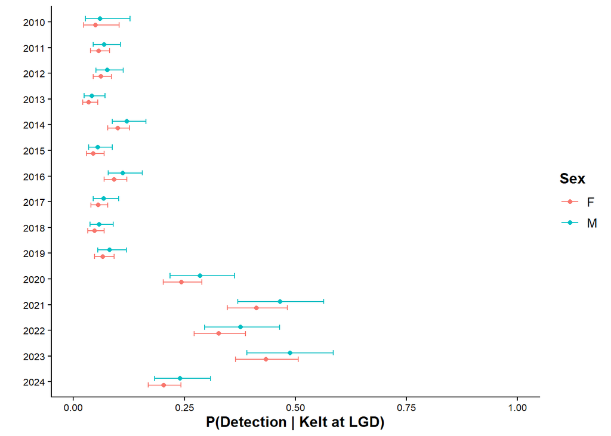

Figure 3.1: Estimated detection probability from the best fitting model of steelhead kelt at Lower Granite Dam after being observed in Snake River basin spawning areas.

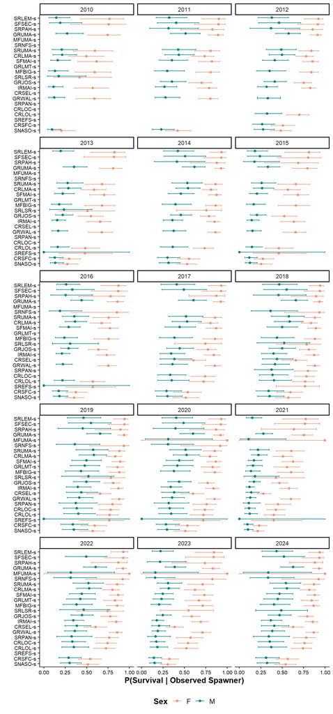

Figure 3.2: Estimated survival probability from the best fitting model of adult steelhead spawners to the kelt life-stage at Lower Granite Dam.

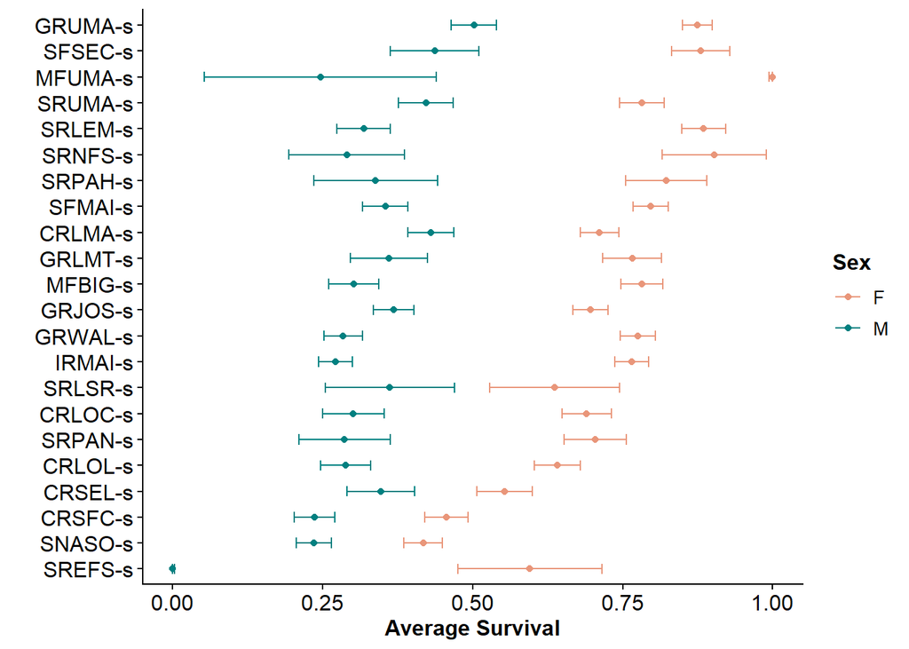

Figure 3.3: Mean survival conditioned on population and sex and marginalized over spawn year for adult natural-origin steelhead spawners surviving to the kelt life-stage at Lower Granite Dam.

Table 3.3: Mean survival conditioned on population and sex and marginalized over spawn years for adult natural-origin steelhead spawners surviving to the kelt life-stage at Lower Granite Dam.

| TRT POPID | Sex | Mean Survival | SE | Lower 95% CI | Upper 95% CI |
| --- | --- | --- | --- | --- | --- |
| MFUMA-s | F | 1.000 | 0.003 | 0.993 | 1.000 |
| SRNFS-s | F | 0.903 | 0.045 | 0.815 | 0.990 |
| SRLEM-s | F | 0.885 | 0.019 | 0.848 | 0.922 |
| SFSEC-s | F | 0.880 | 0.025 | 0.832 | 0.928 |
| GRUMA-s | F | 0.875 | 0.013 | 0.850 | 0.899 |
| SRPAH-s | F | 0.823 | 0.034 | 0.755 | 0.890 |
| SFMAI-s | F | 0.797 | 0.015 | 0.768 | 0.826 |
| SRUMA-s | F | 0.782 | 0.019 | 0.745 | 0.819 |
| MFBIG-s | F | 0.782 | 0.018 | 0.747 | 0.817 |
| GRWAL-s | F | 0.775 | 0.015 | 0.745 | 0.805 |
| GRLMT-s | F | 0.766 | 0.025 | 0.716 | 0.815 |
| IRMAI-s | F | 0.765 | 0.014 | 0.737 | 0.793 |
| CRLMA-s | F | 0.712 | 0.016 | 0.680 | 0.743 |
| SRPAN-s | F | 0.704 | 0.027 | 0.652 | 0.756 |
| GRJOS-s | F | 0.696 | 0.015 | 0.667 | 0.725 |
| CRLOC-s | F | 0.690 | 0.021 | 0.649 | 0.731 |
| CRLOL-s | F | 0.641 | 0.019 | 0.603 | 0.679 |
| SRLSR-s | F | 0.637 | 0.055 | 0.529 | 0.745 |
| SREFS-s | F | 0.595 | 0.061 | 0.475 | 0.716 |
| CRSEL-s | F | 0.553 | 0.024 | 0.507 | 0.599 |
| CRSFC-s | F | 0.456 | 0.018 | 0.420 | 0.493 |
| SNASO-s | F | 0.418 | 0.017 | 0.385 | 0.450 |
| GRUMA-s | M | 0.502 | 0.019 | 0.465 | 0.539 |
| SFSEC-s | M | 0.437 | 0.038 | 0.363 | 0.511 |
| CRLMA-s | M | 0.431 | 0.019 | 0.393 | 0.469 |
| SRUMA-s | M | 0.422 | 0.023 | 0.377 | 0.468 |
| GRJOS-s | M | 0.368 | 0.017 | 0.334 | 0.403 |
| SRLSR-s | M | 0.362 | 0.055 | 0.255 | 0.469 |
| GRLMT-s | M | 0.360 | 0.033 | 0.296 | 0.425 |
| SFMAI-s | M | 0.355 | 0.019 | 0.317 | 0.392 |
| CRSEL-s | M | 0.347 | 0.029 | 0.291 | 0.404 |
| SRPAH-s | M | 0.339 | 0.052 | 0.236 | 0.441 |
| SRLEM-s | M | 0.319 | 0.023 | 0.274 | 0.363 |
| MFBIG-s | M | 0.302 | 0.021 | 0.260 | 0.344 |
| CRLOC-s | M | 0.301 | 0.026 | 0.250 | 0.352 |
| SRNFS-s | M | 0.290 | 0.049 | 0.194 | 0.387 |
| CRLOL-s | M | 0.288 | 0.021 | 0.246 | 0.330 |
| SRPAN-s | M | 0.287 | 0.039 | 0.211 | 0.363 |
| GRWAL-s | M | 0.284 | 0.016 | 0.252 | 0.317 |
| IRMAI-s | M | 0.271 | 0.015 | 0.243 | 0.300 |
| MFUMA-s | M | 0.246 | 0.099 | 0.053 | 0.440 |
| CRSFC-s | M | 0.237 | 0.017 | 0.203 | 0.271 |
| SNASO-s | M | 0.236 | 0.015 | 0.206 | 0.265 |
| SREFS-s | M | 0.000 | 0.001 | 0.000 | 0.003 |

Table 3.4: Mean survival conditioned on year and sex and marginalized over populations for adult natural-origin steelhead spawners surviving to the kelt life-stage at Lower Granite Dam.

| Spawn Year | Sex | Mean Survival | SE | Lower 95% CI | Upper 95% CI |
| --- | --- | --- | --- | --- | --- |
| 2010 | F | 0.578 | 0.039 | 0.502 | 0.654 |
| 2010 | M | 0.167 | 0.021 | 0.125 | 0.208 |
| 2011 | F | 0.784 | 0.021 | 0.742 | 0.825 |
| 2011 | M | 0.350 | 0.028 | 0.294 | 0.406 |
| 2012 | F | 0.785 | 0.017 | 0.752 | 0.817 |
| 2012 | M | 0.390 | 0.025 | 0.342 | 0.439 |
| 2013 | F | 0.603 | 0.027 | 0.551 | 0.656 |
| 2013 | M | 0.194 | 0.017 | 0.161 | 0.228 |
| 2014 | F | 0.811 | 0.016 | 0.780 | 0.842 |
| 2014 | M | 0.434 | 0.025 | 0.385 | 0.482 |
| 2015 | F | 0.596 | 0.027 | 0.544 | 0.649 |
| 2015 | M | 0.181 | 0.016 | 0.151 | 0.212 |
| 2016 | F | 0.699 | 0.022 | 0.655 | 0.744 |
| 2016 | M | 0.255 | 0.019 | 0.218 | 0.293 |
| 2017 | F | 0.788 | 0.017 | 0.754 | 0.822 |
| 2017 | M | 0.414 | 0.025 | 0.365 | 0.462 |
| 2018 | F | 0.823 | 0.015 | 0.793 | 0.853 |
| 2018 | M | 0.460 | 0.026 | 0.409 | 0.511 |
| 2019 | F | 0.824 | 0.015 | 0.795 | 0.852 |
| 2019 | M | 0.437 | 0.023 | 0.391 | 0.483 |
| 2020 | F | 0.801 | 0.014 | 0.773 | 0.829 |
| 2020 | M | 0.375 | 0.023 | 0.329 | 0.421 |
| 2021 | F | 0.539 | 0.020 | 0.499 | 0.579 |
| 2021 | M | 0.143 | 0.012 | 0.120 | 0.165 |
| 2022 | F | 0.805 | 0.014 | 0.778 | 0.833 |
| 2022 | M | 0.402 | 0.025 | 0.353 | 0.451 |
| 2023 | F | 0.654 | 0.020 | 0.616 | 0.692 |
| 2023 | M | 0.215 | 0.016 | 0.184 | 0.247 |
| 2024 | F | 0.821 | 0.012 | 0.798 | 0.845 |
| 2024 | M | 0.425 | 0.025 | 0.376 | 0.475 |

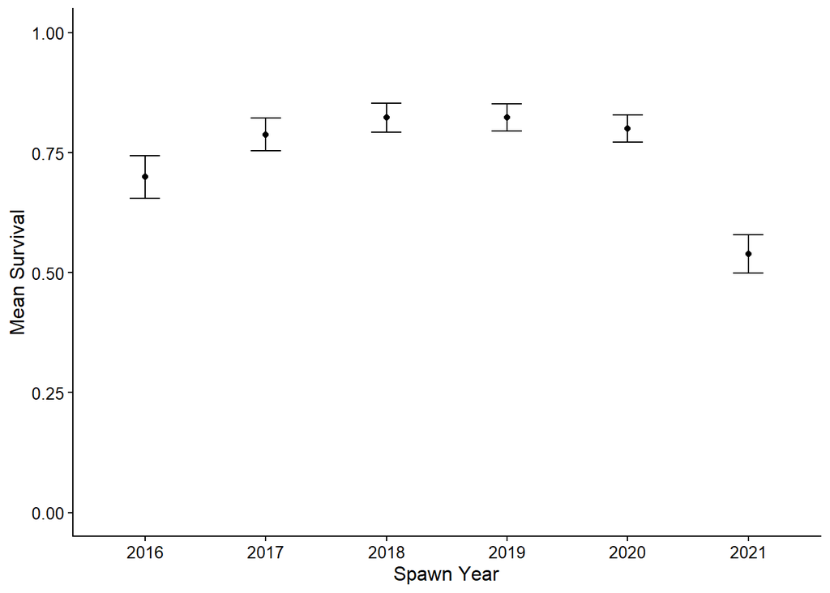

Figure 3.4: Mean survival conditioned on year and sex marginalized over populations for adult natural-origin steelhead spawners surviving to the kelt life-stage at Lower Granite Dam, females only and for spawn years 2016 - 2021.

# References

Agresti, A. 2003. Categorical data analysis. John Wiley & Sons.

Akaike, H. 1974. [A new look at the statistical model identification](https://doi.org/10.1109/TAC.1974.1100705). IEEE Transactions on Automatic Control 19(6):716–723.

Baum, C. M., J. S. Hargrove, A. C. Harris, M. Davison, M. E. Dobos, N. R. Smith, L. Chiaramonte, T. Copeland, and M. R. Campbell. 2023. Wild Adult Steelhead and Chinook Salmon Abundance and Composition at Lower Granite Dam, Spawn Year 2022 2022 Annual Report.

Laake, J. L., D. S. Johnson, and P. B. Conn. 2013. [Marked: An R package for maximum likelihood and Markov Chain Monte Carlo analysis of capture–recapture data](https://doi.org/10.1111/2041-210X.12065). Methods in Ecology and Evolution 4(9):885–890.

Lebreton, J.-D., K. P. Burnham, J. Clobert, and D. R. Anderson. 1992. [Modeling Survival and Testing Biological Hypotheses Using Marked Animals: A Unified Approach with Case Studies](https://doi.org/10.2307/2937171). Ecological Monographs 62(1):67–118.

Ogden, D. 2020. Operation of the Adult Trap at Lower Granite Dam, 2020. BPA Project # 2005-002-00. Page 8.

R Core Team. 2025. [R: A language and environment for statistical computing](https://www.R-project.org/). R Foundation for Statistical Computing, Vienna, Austria.

See, K., R. N. Kinzer, R. Orme, and M. W. Ackerman. 2024. PITcleanr: Cleans up PIT tag capture histories. R package version 3.0.2, commit 8c432d402d587e3a02e8c3c5e0542ee8ff12429e.

Steele, C. A., E. C. Anderson, M. W. Ackerman, M. A. Hess, N. R. Campbell, S. R. Narum, and M. R. Campbell. 2013. [A validation of parentage-based tagging using hatchery steelhead in the Snake River basin](https://doi.org/10.1139/cjfas-2012-0451). Canadian Journal of Fisheries and Aquatic Sciences 70(7):1046–1054.

Steele, C. A., M. Hess, S. Narum, and M. Campbell. 2019. [Parentage-Based Tagging: Reviewing the Implementation of a New Tool for an Old Problem](https://doi.org/10.1002/fsh.10260). Fisheries 44(9):412–422.